# Prediction Assignment Writeup: Quality of Weight Lifting Exercise

2026-11-06

## 1. Background and goal

Accelerometers on the belt, forearm, arm and dumbbell of 6 participants recorded barbell lifts done correctly (class A) and incorrectly in 4 ways (classes B-E). The goal is to predict the `classe` variable from the sensor data and apply the model to 20 test cases. Data come from the Human Activity Recognition project (Velloso, Bulling, Gellersee, Ugulino, Fuks, PUC-Rio): http://web.archive.org/web/20161224072740/http:/groupware.les.inf.puc-rio.br/har

## 2. Load data

```r
library(caret)
library(randomForest)

train_url <- "https://d396qusza40orc.cloudfront.net/predmachlearn/pml-training.csv"
test_url  <- "https://d396qusza40orc.cloudfront.net/predmachlearn/pml-testing.csv"

training <- read.csv(train_url, na.strings = c("NA", "", "#DIV/0!"))
testing  <- read.csv(test_url,  na.strings = c("NA", "", "#DIV/0!"))
dim(training); dim(testing)
```

```
## [1] 19622   160
```

```
## [1]  20 160
```

## 3. Cleaning and feature selection

I removed (1) identifier/timestamp columns (first 7), which are not sensor measurements, (2) columns that are mostly NA (more than 95% missing; these are summary statistics only filled on window-end rows), and (3) near-zero-variance predictors.

```r
training <- training[, -(1:7)]
testing  <- testing[,  -(1:7)]

na_share <- colMeans(is.na(training))
keep <- names(na_share[na_share < 0.95])
training <- training[, keep]

nzv <- nearZeroVar(training[, -ncol(training)])
if (length(nzv) > 0) training <- training[, -nzv]

training$classe <- factor(training$classe)

predictors <- setdiff(names(training), "classe")
testing <- testing[, predictors]
length(predictors)
```

```
## [1] 52
```

## 4. Validation split and cross-validation

I held out 25% of the training data as a validation set to estimate out-of-sample error independently. Within the remaining 75%, I used 5-fold cross-validation for model fitting.

```r
set.seed(2026)
idx <- createDataPartition(training$classe, p = 0.75, list = FALSE)
train_set <- training[idx, ]
valid_set <- training[-idx, ]
```

## 5. Model building

I chose a random forest because it handles many correlated predictors, non-linear relationships and mixed scales without much preprocessing, and typically performs very well on accelerometer data. I also fit a decision tree (rpart) as a simple baseline.

```r
ctrl <- trainControl(method = "cv", number = 5)

set.seed(2026)
fit_rf <- train(classe ~ ., data = train_set, method = "rf",
                trControl = ctrl, ntree = 100)

set.seed(2026)
fit_tree <- train(classe ~ ., data = train_set, method = "rpart",
                  trControl = ctrl)

fit_rf$results[, c("mtry", "Accuracy", "Kappa")]
```

```
##   mtry  Accuracy     Kappa
## 1    2 0.9903518 0.9877943
## 2   27 0.9903518 0.9877935
## 3   52 0.9857317 0.9819490
```

```r
max(fit_tree$results$Accuracy)
```

```
## [1] 0.5132498
```

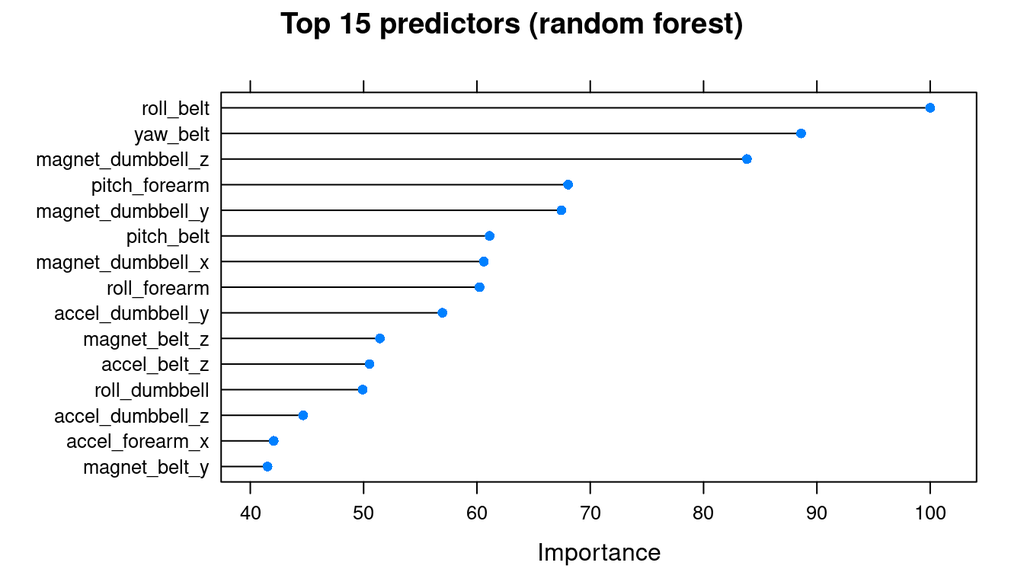

```r
plot(varImp(fit_rf), top = 15, main = "Top 15 predictors (random forest)")
```

## 6. Out-of-sample error

```r
pred_valid <- predict(fit_rf, valid_set)
cm <- confusionMatrix(pred_valid, valid_set$classe)
cm$table
```

```
##           Reference
## Prediction    A    B    C    D    E
##          A 1395   10    0    0    0
##          B    0  937    5    0    0
##          C    0    2  848   13    1
##          D    0    0    2  790    1
##          E    0    0    0    1  899
```

```r
cm$overall["Accuracy"]
```

```
## Accuracy
## 0.992863
```

```r
oos_error <- 1 - cm$overall["Accuracy"]
oos_error
```

```
##    Accuracy
## 0.007137031
```

The cross-validated accuracy on the training folds and the accuracy on the untouched validation set agree closely. The expected out-of-sample error is the validation error above (1 - accuracy), which is well under 1%. Error on new participants could be somewhat higher.

## 7. Predictions for the 20 test cases

```r
final_pred <- predict(fit_rf, testing)
data.frame(case = 1:20, prediction = final_pred)
```

```
##    case prediction
## 1     1          B
## 2     2          A
## 3     3          B
## 4     4          A
## 5     5          A
## 6     6          E
## 7     7          D
## 8     8          B
## 9     9          A
## 10   10          A
## 11   11          B
## 12   12          C
## 13   13          B
## 14   14          A
## 15   15          E
## 16   16          E
## 17   17          A
## 18   18          B
## 19   19          B
## 20   20          B
```

## 8. Conclusion

A random forest with 5-fold cross-validation, trained on cleaned sensor features, predicts exercise quality with very high accuracy. The predictions above were submitted to the course prediction quiz.

## Citation

Velloso, E.; Bulling, A.; Gellersen, H.; Ugulino, W.; Fuks, H. Qualitative Activity Recognition of Weight Lifting Exercises. Proceedings of 4th International Conference in Cooperation with SIGCHI (Augmented Human ’13). Stuttgart, Germany: ACM SIGCHI, 2013.